# F9_02_PREP_PERS_PTIN

Preparer PTIN · Identifier report

## Overview

**Description**

Paid Preparer PTIN

**Table**

`F9-P02-T00-SIGNATURE` (one)

**Location code**

`F990-PC-PART-02`

**Family**

`F990-PC-PART-02` · siblings: F9_02_DISC_PREP_THIRD_PARTY_X, F9_02_PREP_FIRM_ADDR_CITY, F9_02_PREP_FIRM_ADDR_CNTR, F9_02_PREP_FIRM_ADDR_L1, F9_02_PREP_FIRM_ADDR_L2, F9_02_PREP_FIRM_ADDR_STATE

**Data type**

numeric (xsd: PTINType)

**Scope**

SG

**Status**

unreviewed

2

xpaths mapped (2 observed)

4,788,420

filings with a value

2010–2024

tax years observed

4

open flags (0 errors)

## Flags

| Severity | Flag | Xpath | Detail |
| --- | --- | --- | --- |
| ▲ warn | `INCIDENCE_BREAK` |  | 990 fill rate changes up to 2033.7x year-on-year (in 2011) |
| ▲ warn | `INCIDENCE_BREAK` |  | 990EZ fill rate changes up to 1398.4x year-on-year (in 2011) |
| ▲ warn | `TYPE_NUMERIC` | PreparerPersonGrp/PTIN | numeric variable; 0% of values parse as numbers |
| ▲ warn | `TYPE_NUMERIC` | Preparer/PTIN | numeric variable; 0% of values parse as numbers |

## Xpaths

All mapped xpaths (under /Return/ReturnData or /Return/ReturnHeader), oldest first. Charts label each series by its xpath.

| Xpath | Form | First year | Last year | Versions | Filings | Repeats in |
| --- | --- | --- | --- | --- | --- | --- |
| Preparer/PTIN | Header | 2010 | 2012 | 9 | 244,751 | 0.0% |
| PreparerPersonGrp/PTIN | Header | 2013 | 2024 | 37 | 4,543,669 | 0.0% |

## Coverage

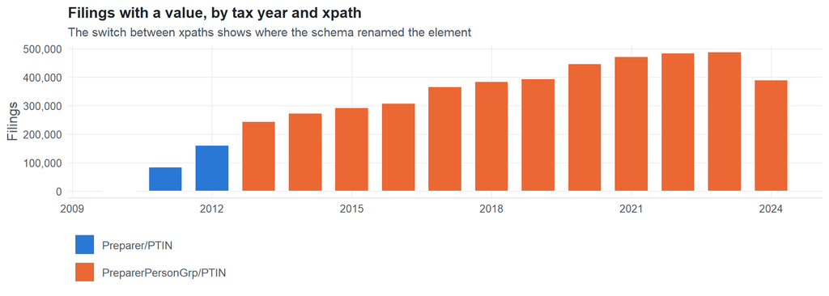

**Table view**

Table view: filings by tax year and series

| Tax year | Preparer/PTIN | PreparerPersonGrp/PTIN |
| --- | --- | --- |
| 2010 | 35 | 0 |
| 2011 | 84,035 | 0 |
| 2012 | 160,681 | 0 |
| 2013 | 0 | 244,033 |
| 2014 | 0 | 273,366 |
| 2015 | 0 | 293,034 |
| 2016 | 0 | 307,485 |
| 2017 | 0 | 366,398 |
| 2018 | 0 | 384,272 |
| 2019 | 0 | 394,187 |
| 2020 | 0 | 447,111 |
| 2021 | 0 | 472,264 |
| 2022 | 0 | 484,236 |
| 2023 | 0 | 487,867 |
| 2024 | 0 | 389,416 |

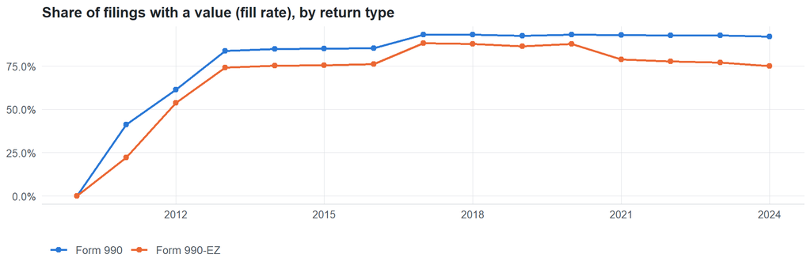

**Table view**

Table view: fill rate

| Tax year | Return type | Filings | All filings | Fill rate |
| --- | --- | --- | --- | --- |
| 2010 | Form 990 | 25 | 123,025 | 0.02% |
| 2010 | Form 990-EZ | 10 | 63,326 | 0.02% |
| 2011 | Form 990 | 65,917 | 159,504 | 41.33% |
| 2011 | Form 990-EZ | 18,118 | 82,048 | 22.08% |
| 2012 | Form 990 | 110,231 | 179,688 | 61.35% |
| 2012 | Form 990-EZ | 50,450 | 93,750 | 53.81% |
| 2013 | Form 990 | 166,633 | 198,855 | 83.80% |
| 2013 | Form 990-EZ | 77,400 | 104,375 | 74.16% |
| 2014 | Form 990 | 185,635 | 218,619 | 84.91% |
| 2014 | Form 990-EZ | 87,731 | 116,417 | 75.36% |
| 2015 | Form 990 | 198,843 | 233,519 | 85.15% |
| 2015 | Form 990-EZ | 94,191 | 124,894 | 75.42% |
| 2016 | Form 990 | 208,026 | 243,903 | 85.29% |
| 2016 | Form 990-EZ | 99,459 | 130,484 | 76.22% |
| 2017 | Form 990 | 243,643 | 261,612 | 93.13% |
| 2017 | Form 990-EZ | 122,755 | 139,144 | 88.22% |
| 2018 | Form 990 | 252,996 | 271,442 | 93.20% |
| 2018 | Form 990-EZ | 131,276 | 149,384 | 87.88% |
| 2019 | Form 990 | 262,281 | 283,694 | 92.45% |
| 2019 | Form 990-EZ | 131,905 | 152,622 | 86.43% |
| 2020 | Form 990 | 298,081 | 320,342 | 93.05% |
| 2020 | Form 990-EZ | 149,028 | 169,864 | 87.73% |
| 2021 | Form 990 | 312,627 | 336,480 | 92.91% |
| 2021 | Form 990-EZ | 159,624 | 202,724 | 78.74% |
| 2022 | Form 990 | 323,866 | 349,055 | 92.78% |
| 2022 | Form 990-EZ | 160,359 | 206,130 | 77.80% |
| 2023 | Form 990 | 328,858 | 354,768 | 92.70% |
| 2023 | Form 990-EZ | 159,000 | 206,379 | 77.04% |
| 2024 | Form 990 | 255,285 | 277,298 | 92.06% |
| 2024 | Form 990-EZ | 134,126 | 178,867 | 74.99% |

## Values

| Result | Check | Detail |
| --- | --- | --- |
| ✓ pass | Values have the PTIN format | 100.0% of values match ^A99999999$ |
| ⚠ fail | Stored as text | data type is numeric: leading zeros and letters would be lost |
| ✓ pass | No placeholder values | no all-zero / all-nine placeholders among the most common values |
| ✓ pass | Leading zeros present | no evidence of leading zeros |

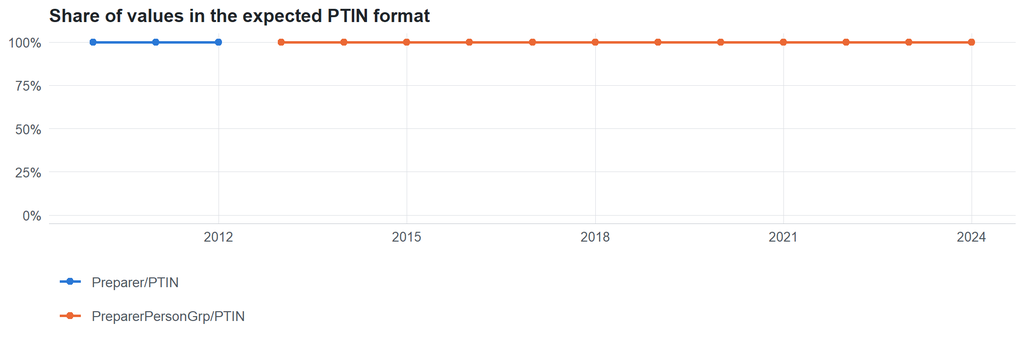

Value shapes (9 = digit, A = letter)

| Series | Shape | Expected | Filings |
| --- | --- | --- | --- |
| Preparer/PTIN | A99999999 | yes | 244,751 |
| PreparerPersonGrp/PTIN | A99999999 | yes | 4,543,669 |

## Examples

| Tax year | Return | Xpath | Organization | Value | Source |
| --- | --- | --- | --- | --- | --- |
| 2024 | 990EZ | PreparerPersonGrp/PTIN | SAINT CLAIR HOUSE INC | P00437640 | [XML](https://gt990datalake-rawdata.s3.amazonaws.com/EfileData/XmlFiles/202521329349201597_public.xml) |
| 2023 | 990EZ | PreparerPersonGrp/PTIN | SAN ANTONIO HOMESCHOOL ATHLETIC ASSOICATION | P00757404 | [XML](https://gt990datalake-rawdata.s3.amazonaws.com/EfileData/XmlFiles/202432609349201843_public.xml) |
| 2022 | 990 | PreparerPersonGrp/PTIN | FRANK TOWN OPEN HEARTS MINISTRY INC | P01360716 | [XML](https://gt990datalake-rawdata.s3.amazonaws.com/EfileData/XmlFiles/202303189349302170_public.xml) |
| 2021 | 990 | PreparerPersonGrp/PTIN | COULEE REGION HUMANE SOCIETY INC | P00583499 | [XML](https://gt990datalake-rawdata.s3.amazonaws.com/EfileData/XmlFiles/202243119349301379_public.xml) |
| 2020 | 990EZ | PreparerPersonGrp/PTIN | ESAN UNITED DALLAS FORT WORTH | P01793163 | [XML](https://gt990datalake-rawdata.s3.amazonaws.com/EfileData/XmlFiles/202143169349202839_public.xml) |
| 2019 | 990 | PreparerPersonGrp/PTIN | PROJECT KENYA INC | P00217200 | [XML](https://gt990datalake-rawdata.s3.amazonaws.com/EfileData/XmlFiles/202013079349301106_public.xml) |
| 2018 | 990EZ | PreparerPersonGrp/PTIN | Woodlawn Cemetery Association Inc | P00293744 | [XML](https://gt990datalake-rawdata.s3.amazonaws.com/EfileData/XmlFiles/201933179349200908_public.xml) |
| 2017 | 990 | PreparerPersonGrp/PTIN | WAKONDA CLUB | P01480921 | [XML](https://gt990datalake-rawdata.s3.amazonaws.com/EfileData/XmlFiles/201932569349300073_public.xml) |
| 2016 | 990 | PreparerPersonGrp/PTIN | THE ASSOC OF MARITAL & FAMILY | P00148500 | [XML](https://gt990datalake-rawdata.s3.amazonaws.com/EfileData/XmlFiles/201721319349304097_public.xml) |
| 2015 | 990 | PreparerPersonGrp/PTIN | THE UNIVERSITY OF QUEENSLAND IN AMERICA | P00022087 | [XML](https://gt990datalake-rawdata.s3.amazonaws.com/EfileData/XmlFiles/201622109349300832_public.xml) |
| 2014 | 990EZ | PreparerPersonGrp/PTIN | AERIAL EAST BOOSTER CLUB INC | P00015687 | [XML](https://gt990datalake-rawdata.s3.amazonaws.com/EfileData/XmlFiles/201523149349200707_public.xml) |
| 2013 | 990EZ | PreparerPersonGrp/PTIN | Awesome Cooper Band Boosters | P00692078 | [XML](https://gt990datalake-rawdata.s3.amazonaws.com/EfileData/XmlFiles/201423079349200717_public.xml) |

## Reviewer checklist

- The definition matches the form line and instructions for every xpath’s schema years.
- Every xpath pooled here measures the same thing on the 990 and 990-EZ (close enough for analysis).
- The coverage chart has no unexplained gaps or jumps between tax years.
- Each open flag is fixed, or accepted with a note in validation_log.csv.
- The data type is text so leading zeros and letters survive.
- The identifier belongs to the entity the variable names (the filer, preparer, related organization…).
- Formats with and without punctuation (e.g. ZIP+4, dashes) are normalized consistently downstream.

Record the review as a row in `inst/extdata/src/validation_log.csv` (variable_name, reviewer, date, status, note). Evidence built 2026-09-23 17:09:04 MST from the ef2 DuckDB builds (tax years 2009–2024).